# Slovakia

Institutional Module

The Community Trust Index measures the level of trust in the Slovak Red Cross by assessing its competencies and core values. It examines key subdimensions that shape trust perceptions, alongside community views on the Institutional module. The findings highlight both strengths and areas for improvement, with the aim of strengthening community engagement and guiding policy development. Ultimately, the index seeks to foster a more trusted and cohesive environment, contributing to Slovakia’s sustainable development and the well-being of its communities.

# Sampling

The sampling employed a random stratified approach in selected districts where the Slovak Red Cross (SRC) operates. Stratification was based on age group, gender, with additional distinctions made between migrant and host community populations to ensure representation across diverse communities.

*See metrics: Metrics*

The sample distribution broadly reflects the population structure across the selected regions and provinces within Slovakia. Most notably, Bratislava is heavily under-represented, comprising only 8.8% of the sample despite accounting for 42.4% of the actual population. In contrast, respondents from Central and Eastern Slovakia are over-represented; Central Slovakia makes up 35.1% of the survey (vs. 13.6% population), and Eastern Slovakia sits at 39.4% (vs. 27% population). Western Slovakia is the only region where the sampling (16.7%) closely aligns with the population benchmark (17.1%).

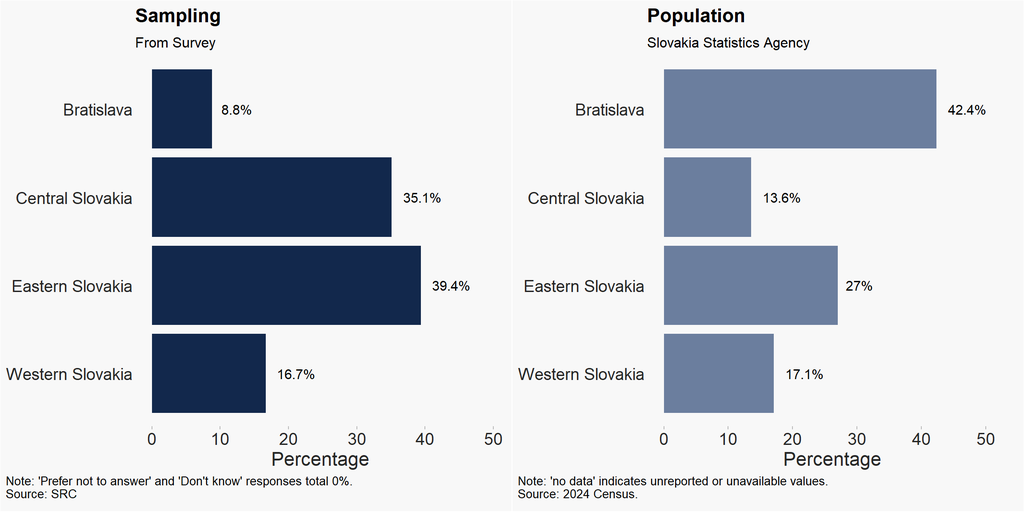

[interactive chart not shown]

The sample broadly reflects the population structure by age and gender. Women 35+ are well aligned with census data, though women 18-34 are slightly over-represented. Among men, the 18–34 group is close to population levels, while men 35-49 are under-represented. Also, men above 40 are under-represented slightly. These small imbalances may require post-stratification adjustment.

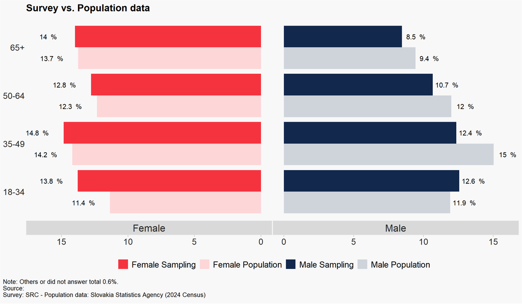

The education profile of the sample is closely aligned with population data. University and secondary levels match well (23.3% vs. 22.7% and 40.7% vs. 43.4%). Primary education is slightly under-represented (24.7% vs. 27.6%), while those with no formal education are somewhat over-represented (11.2% vs. 6.4%).

The data presented in this study should be interpreted with caution due to methodological limitations related to sampling and representativeness. While the survey provides valuable insights, certain groups and regions are over- or under-represented compared with census distributions. For example, Bratislava province is under-represented, women aged 18-34 are over-represented, and most men age groups are under-represented.

To reduce these imbalances, post-stratification adjustments were applied using key variables such as age, gender, education, and employment status. These corrections improve comparability but cannot fully eliminate bias introduced by the sampling approach. As a result, the findings should be viewed as broadly indicative rather than fully representative of the wider population, and caution is advised when generalizing beyond the surveyed groups.

# Survey Results

The charts below present the survey answers as percentages, offering visualization of the Community Trust levels by subdimensions. They illustrate the distribution of community’s perceptions of the competencies and values.

## Perception of trust

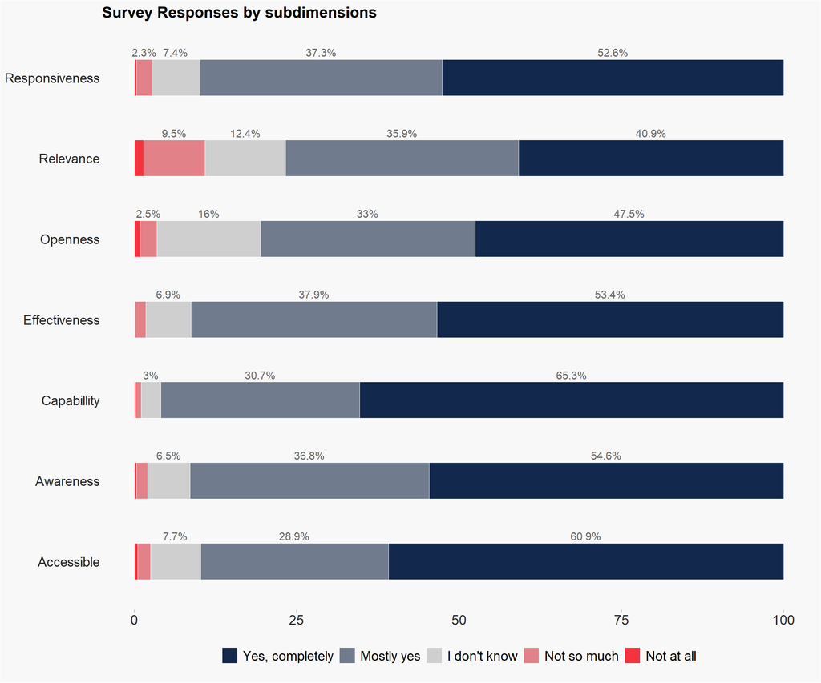

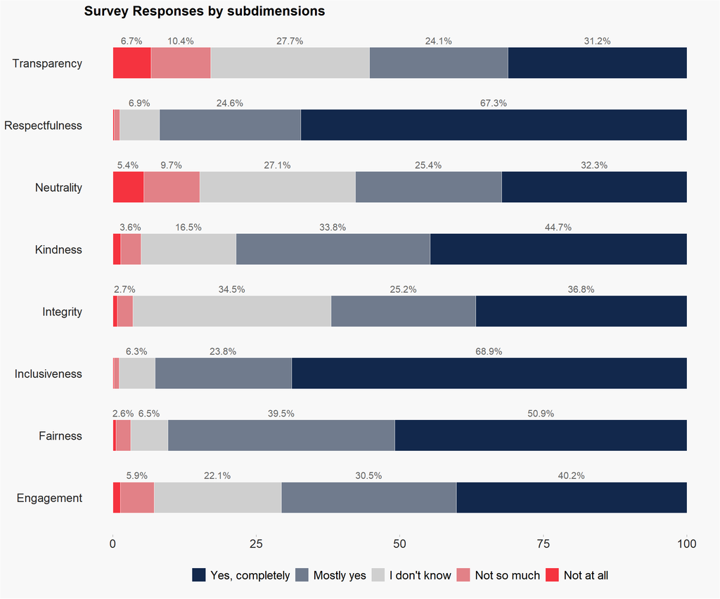

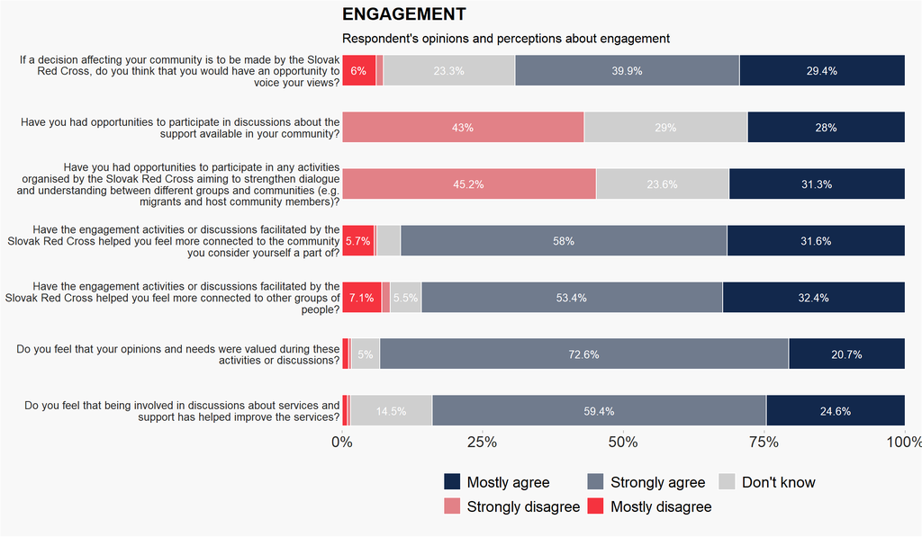

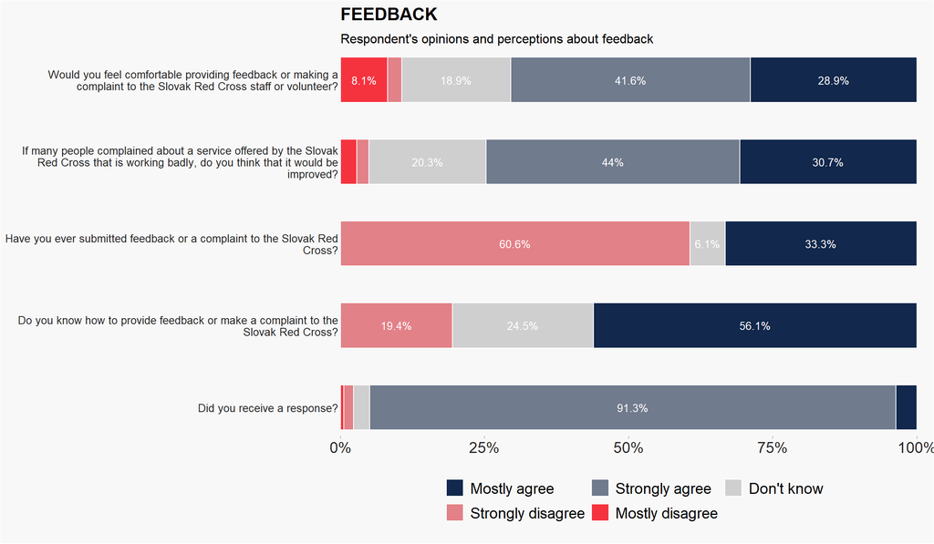

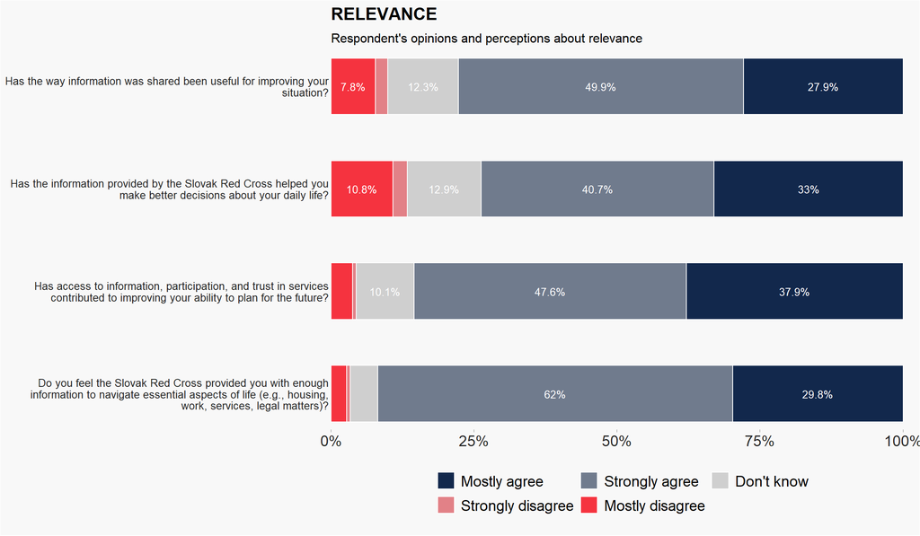

## Contextual questions

This section presents findings on community members’ experiences with and behaviors toward the Red Cross. These questions explore interactions, perceptions, and engagement patterns, offering insights into how the Red Cross is viewed and utilized within the community.

Though only 37.6% received support, engagement outcomes are highly positive. Around 83% said engagement improved their life situation. Over 50% reported that migrant support activities positively influenced their trust and perception, while nearly a third saw no change, indicating strengthened reputation without significant alienation.

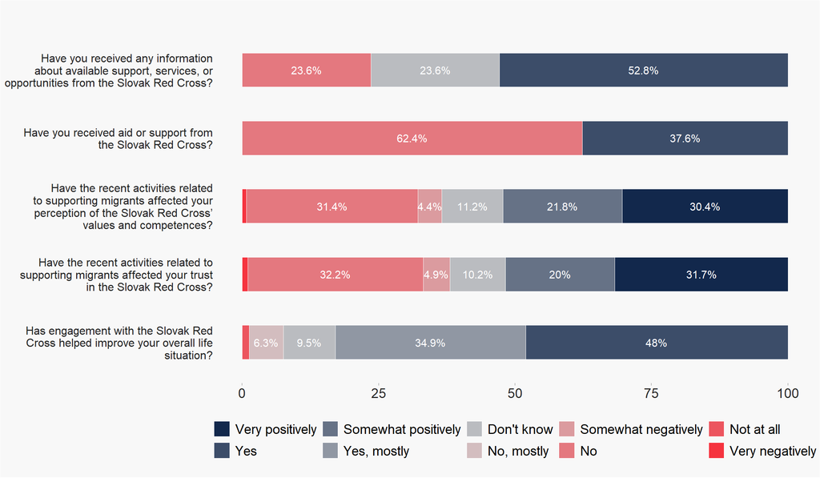

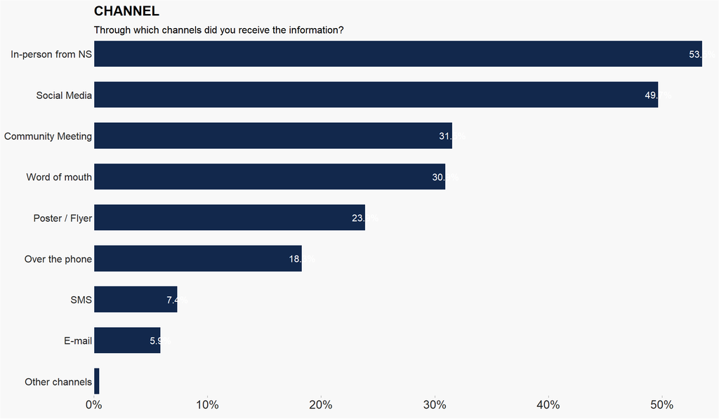

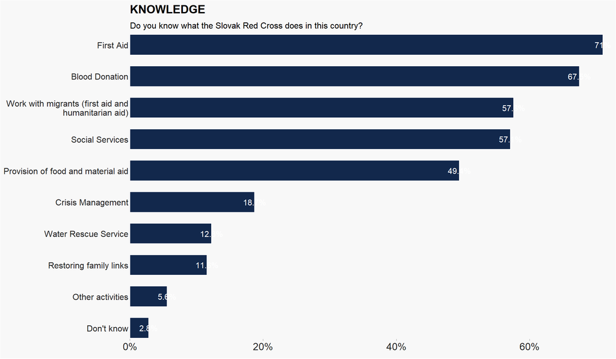

# Score

This score is derived from responses to questions that assess perceptions of competencies and values, providing a comprehensive measure of trust. A higher score indicates stronger trust, suggesting that community members believe their needs are being addressed and their values are respected. *Learn more about scoring method: Methods*

## Overall Score

The following chart presents an analysis of competencies and values, each rated on a scale from 0 to 10. For competencies, the strongest perceptions are in **Effectiveness (8.84)**, **Awareness (8.81)**, and **Capability (8.8)**, while **Relevance (7.46)** scores the lowest, highlighting an area where improvement may be needed.

For values, the highest ratings are for **Inclusiveness (9.36)**, **Respectfulness (9.34)**, and **Integrity (8.75)**, reflecting positive perceptions of these qualities. In contrast, **Transparency (6.74)** and **Neutrality (7.4)** score significantly lower, suggesting challenges in these dimensions.

*Learn more about weighting process: Weighting*

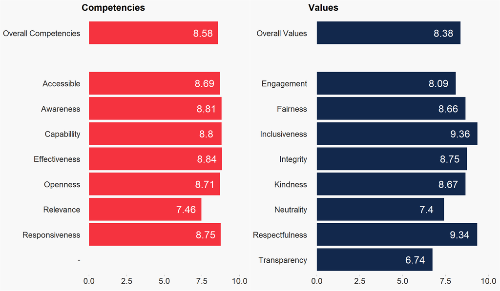

## Score by factors

*Distribution of mean scores for values and competencies per demographic questions*

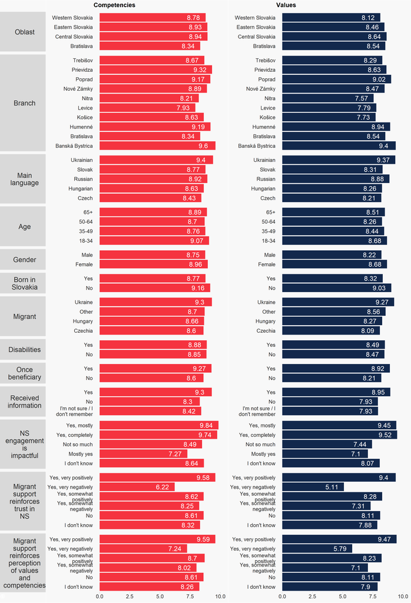

## Score by respondent profile

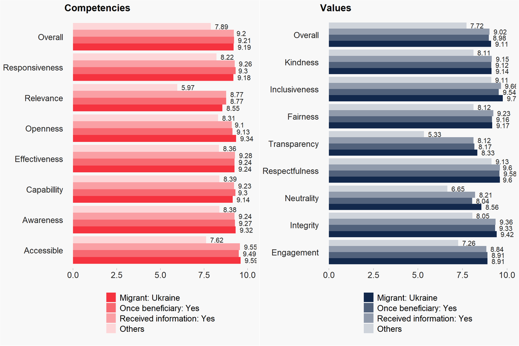

# Methods and Metrics

### Gender

Respondents by Gender

| Gender | Total Respondents | Percentage (%) |
| --- | --- | --- |
| Female | 1053 | 55.4 |
| Male | 838 | 44.1 |
| Other or did not answer | 11 | 0.6 |
| Total | 1902 | 100.0 |

### Age

Respondents by Age Group

| Age Group | Total Respondents | Percentage (%) |
| --- | --- | --- |
| 18-34 | 504 | 26.5 |
| 35-49 | 520 | 27.3 |
| 50-64 | 449 | 23.6 |
| 65+ | 429 | 22.6 |

### Geographic

Respondents by Kraj and Oblast

| Oblast | Kraj | Total Respondents | Percentage (%) |
| --- | --- | --- | --- |
| Bratislava | Bratislava | 168 | 100.0 |
| Bratislava | TOTAL | 168 | 100.0 |
| Central Slovakia | Nitra | 468 | 70.1 |
| Central Slovakia | Banská Bystrica | 200 | 29.9 |
| Central Slovakia | TOTAL | 668 | 100.0 |
| Eastern Slovakia | Prešov | 406 | 54.2 |
| Eastern Slovakia | Košice | 343 | 45.8 |
| Eastern Slovakia | TOTAL | 749 | 100.0 |
| Western Slovakia | Nitra | 160 | 50.5 |
| Western Slovakia | Trenčín | 157 | 49.5 |
| Western Slovakia | TOTAL | 317 | 100.0 |

### Relationship with RC

Respondents by relationship with RC

| Profile | Total Respondents |
| --- | --- |
| Migrant: Ukraine | 323 |
| Once beneficiary: Yes | 716 |
| Received information: Yes | 1005 |

**Scoring methodology**

To determine the score, we employ the following method:

1. Survey Structure The CTI survey includes multiple questions grouped under sub-dimensions of two main categories:
   - Competencies (e.g., reliability, effectiveness, technical proficiency)
   - Values (e.g., ethics, integrity, fairness, transparency)
2. Sub-Dimension Scoring

   Each sub-dimension comprises several survey items (questions).Respondents answer on a Likert-type scale (1 to 4 - Don’t not is excluded). For each sub-dimension:

   *Sub-dimension Score = ∑ (Weighted Response Scores) / Number of Items*

If weights are not empirically derived, equal weighting is typically applied to each item.

3. Dimension Scoring

Once all sub-dimension scores are calculated, the Competency Score and Values Score are each derived as the arithmetic mean of their respective sub-dimension scores:

- *Competency Score = ∑(Sub-dimension Scores for Competency) /𝑛*
- *Values Score = ∑(Sub-dimension Scores for Values)/𝑚*

where 𝑛 and 𝑚 are the number of sub-dimensions in each category.

4. Overall Scoring

   The final Community Trust Index score is the arithmetic mean of the Competency and Values scores:
- *CTI Score = (Competency Score + Values Score)/2*

**Weighting vs. unweighting**

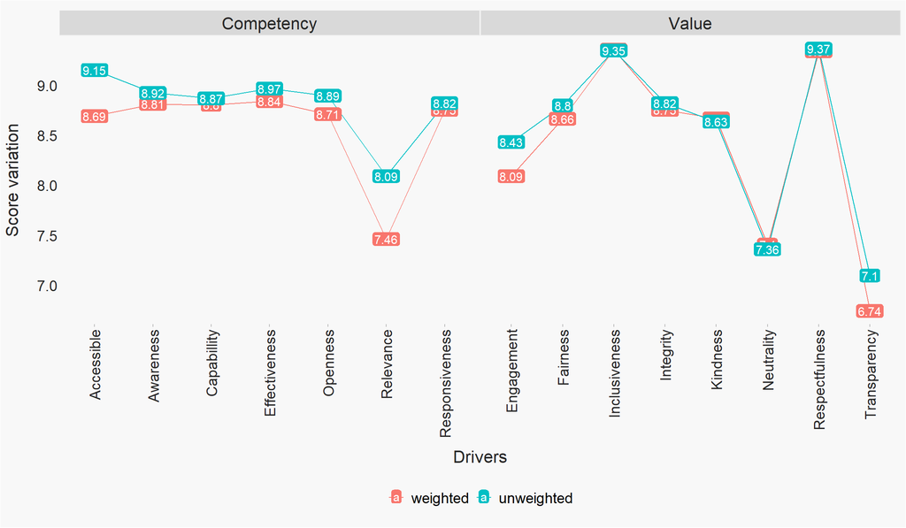

**Correlation matrix**

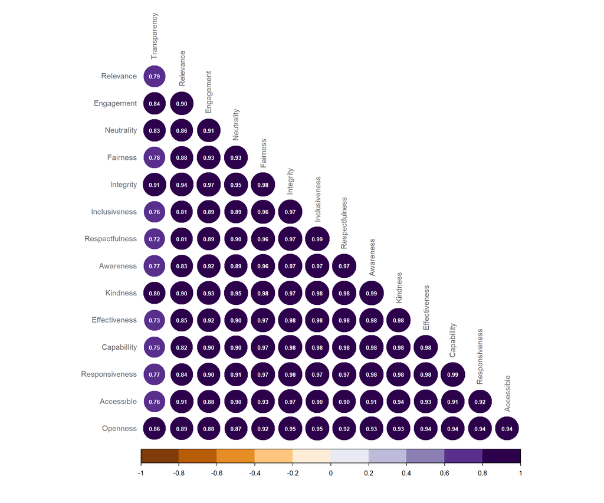

**Significance testing**

| Pillar | Drivers | Migrant: Ukraine-Once beneficiary: Yes | Migrant: Ukraine-Others | Once beneficiary: Yes-Others |
| --- | --- | --- | --- | --- |
| Competency | Capabillity | No | Yes | Yes |
| Competency | Responsiveness | No | Yes | Yes |
| Competency | Awareness | No | Yes | Yes |
| Competency | Accessible | Yes | Yes | Yes |
| Competency | Relevance | No | Yes | Yes |
| Competency | Effectiveness | No | Yes | Yes |
| Competency | Openness | No | Yes | Yes |
| Value | Kindness | No | Yes | Yes |
| Value | Fairness | No | Yes | Yes |
| Value | Inclusiveness | Yes | Yes | Yes |
| Value | Respectfulness | Yes | Yes | Yes |
| Value | Engagement | No | Yes | Yes |
| Value | Integrity | No | Yes | Yes |
| Value | Neutrality | Yes | Yes | Yes |
| Value | Transparency | No | Yes | Yes |

# Download

Download Summary Excel File